# lab10

```r
# spatial data science
library(tidyverse)
library(sf)
library(units)
# Data
library(AOI)

# Visualization
library(gghighlight)
library(ggrepel)
library(knitr)
```

```r
eqdc <- '+proj=eqdc +lat_0=40 +lon_0=-96 +lat_1=20 +lat_2=60 +x_0=0 +y_0=0 +datum=NAD83 +units=m +no_defs'

aoi_get(state = 'conus')
```

```
Simple feature collection with 49 features and 14 fields
Geometry type: MULTIPOLYGON
Dimension:     XY
Bounding box:  xmin: -124.8485 ymin: 24.39631 xmax: -66.88544 ymax: 49.38448
Geodetic CRS:  WGS 84
First 10 features:
   state_region state_division feature_code           state_name state_abbr
1             3              6      1779775              Alabama         AL
2             4              8      1779777              Arizona         AZ
3             3              7      0068085             Arkansas         AR
4             4              9      1779778           California         CA
5             4              8      1779779             Colorado         CO
6             1              1      1779780          Connecticut         CT
7             3              5      1779781             Delaware         DE
8             3              5      1702382 District of Columbia         DC
```

[output cut: 35 more lines]

```r
aoi_get(country = c("MX", "USA", "CA"))
```

```
Simple feature collection with 3 features and 168 fields
Geometry type: MULTIPOLYGON
Dimension:     XY
Bounding box:  xmin: -171.7911 ymin: 14.53883 xmax: -52.6481 ymax: 83.23324
Geodetic CRS:  WGS 84
        featurecla scalerank labelrank               sovereignt sov_a3 adm0_dif
4  Admin-0 country         1         2                   Canada    CAN        0
5  Admin-0 country         1         2 United States of America    US1        1
28 Admin-0 country         1         2                   Mexico    MEX        0
   level              type tlc                    admin adm0_a3 geou_dif
4      2 Sovereign country   1                   Canada     CAN        0
5      2           Country   1 United States of America     USA        0
28     2 Sovereign country   1                   Mexico     MEX        0
                    geounit gu_a3 su_dif       subunit su_a3 brk_diff
4                    Canada   CAN      0        Canada   CAN        0
```

[output cut: 106 more lines]

```r
eqdc <- st_crs(5070)
```

While this data has everything we want, it is not yet spatial. Convert the data.frame to a spatial object using st_as_sf and prescribing the coordinate variables and CRS (Hint what projection are the raw coordinates in?)

Finally, remove cities in states not wanted and make sure the data is in a projected coordinate system suitable for distance measurements at the national scale:

Congratulations! You now have three real-world, large datasets ready for analysis.

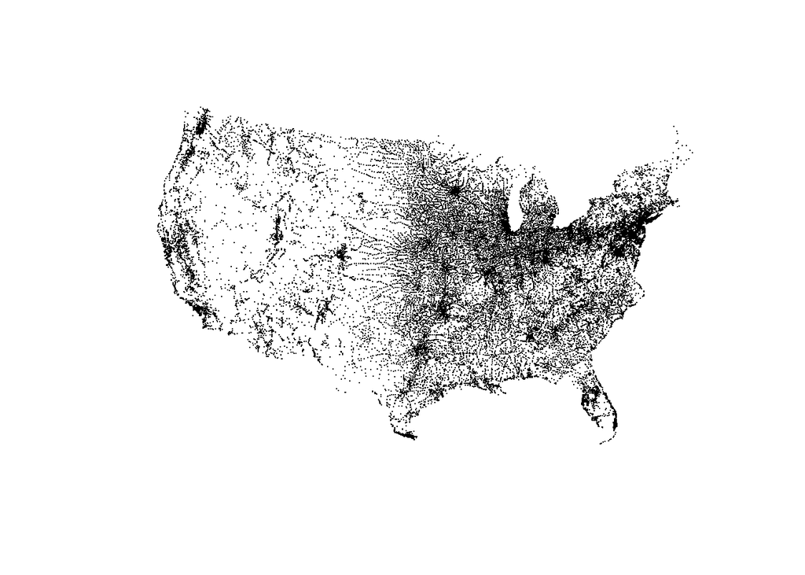

```r
#cities
states <- USAboundaries::us_states(resolution = "low") |>
  filter(!state_abbr %in% c("HI", "AK", "PR")) |>
  st_transform(eqdc)

cities <- read_csv("uscities.csv", show_col_types = FALSE) %>%
  filter(!state_id %in% c("HI", "AK", "PR")) %>%
  st_as_sf(coords = c("lng", "lat"), crs = 4326) %>%
  st_transform(eqdc)

plot(cities$geometry, pch = 16, cex = .1)
```

```r
df <- data.frame(name = state.name,
                X = state.center$x,
                Y = state.center$y)
head(df)
```

```
        name         X       Y
1    Alabama  -86.7509 32.5901
2     Alaska -127.2500 49.2500
3    Arizona -111.6250 34.2192
4   Arkansas  -92.2992 34.7336
5 California -119.7730 36.5341
6   Colorado -105.5130 38.6777
```

```r
(df_sf_gcs = st_as_sf(df,
                      coords = c("X", "Y"),
                      crs = 4269))
```

```
Simple feature collection with 50 features and 1 field
Geometry type: POINT
Dimension:     XY
Bounding box:  xmin: -127.25 ymin: 27.8744 xmax: -68.9801 ymax: 49.25
Geodetic CRS:  NAD83
First 10 features:
          name                 geometry
1      Alabama POINT (-86.7509 32.5901)
2       Alaska    POINT (-127.25 49.25)
3      Arizona POINT (-111.625 34.2192)
4     Arkansas POINT (-92.2992 34.7336)
5   California POINT (-119.773 36.5341)
6     Colorado POINT (-105.513 38.6777)
7  Connecticut POINT (-72.3573 41.5928)
8     Delaware POINT (-74.9841 38.6777)
9      Florida  POINT (-81.685 27.8744)
10     Georgia POINT (-83.3736 32.3329)
```

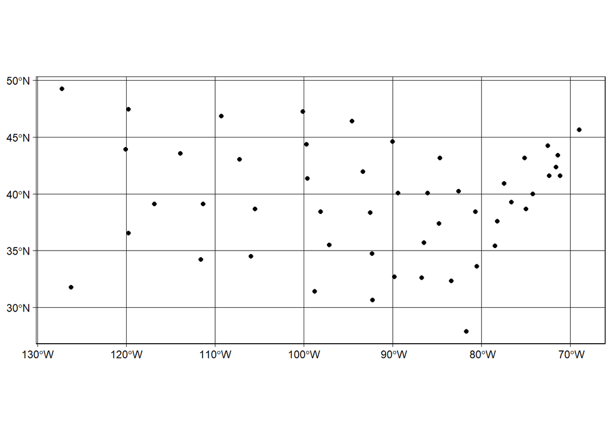

```r
ggplot() +
  geom_sf(data = df_sf_gcs) +
  coord_sf(datum = st_crs(df_sf_gcs)) +
  theme_linedraw()
```

```r
(df_sf_pcs = st_transform(df_sf_gcs, 5070))
```

```
Simple feature collection with 50 features and 1 field
Geometry type: POINT
Dimension:     XY
Bounding box:  xmin: -2805703 ymin: 640477 xmax: 2079664 ymax: 3291437
Projected CRS: NAD83 / Conus Albers
First 10 features:
          name                  geometry
1      Alabama  POINT (862043.5 1099545)
2       Alaska  POINT (-2264853 3291437)
3      Arizona  POINT (-1422260 1356663)
4     Arkansas  POINT (336061.5 1303543)
5   California  POINT (-2086972 1760961)
6     Colorado POINT (-818480.9 1779785)
7  Connecticut   POINT (1936213 2307450)
8     Delaware   POINT (1796466 1938236)
9      Florida    POINT (1409814 640477)
10     Georgia   POINT (1179012 1107322)
```

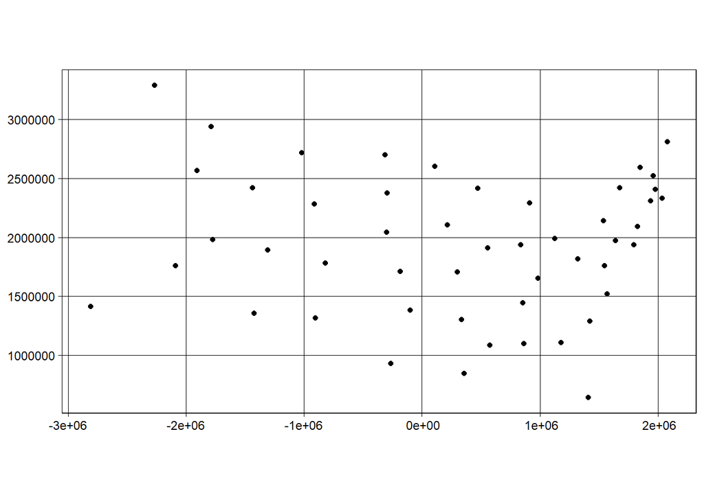

```r
ggplot() +
  geom_sf(data = df_sf_pcs) +
  coord_sf(datum = st_crs(df_sf_pcs)) +
  theme_linedraw()
```

QUESTION 2 2.1 - Distance to USA Border (coastline or national) (km)

```r
library(flextable)
states_union <-st_union(states)
state_boundaries <- st_boundary(states_union)
state_boundaries <- st_cast(state_boundaries, "MULTILINESTRING")

cities_distance <- cities %>%
  mutate(distance_to_border = st_distance(geometry, state_boundaries)) %>%
  mutate(distance_km = as.numeric(distance_to_border) / 1000)

top5_BorderCities <- cities_distance %>%
  arrange(desc(distance_km)) %>%
  slice(1:5) %>%
  select(city, state_id, distance_km)

flextable(top5_BorderCities) %>%
  set_header_labels(city = "City", state_id = "State", distance_km = "Distance to State Border (km)") %>%
  autofit()
```

[output not shown]

2.2 We are interested in calculating the distance of each city to the nearest state boundary. To do this we need all states to act as single unit. Convert the USA state boundaries to a MULTILINESTRING geometry in which the state boundaries are preserved (not resolved). In addition to storing this distance data as part of the cities data.frame, produce a table (flextable) documenting the five cities farthest from a state border. Include only the city name, state, and distance.

```r
library(sf)
library(dplyr)
library(flextable)
library(units)

states_proj <- st_transform(states, 2163)
cities_proj <- st_transform(cities, 2163)

state_boundaries <- st_boundary(states_proj)

state_lines <- st_cast(state_boundaries, "MULTILINESTRING")

all_state_borders <- st_union(state_lines)

cities_proj$dist_to_state_border_km <- st_distance(cities_proj, all_state_borders) %>%
  set_units("km") %>%
  as.numeric()

farthest_cities <- cities_proj %>%
  st_drop_geometry() %>%
  select(city = city, state = state_name, dist_to_state_border_km) %>%
  arrange(desc(dist_to_state_border_km)) %>%
  slice(1:5)


flextable(farthest_cities)
```

| city | state | dist_to_state_border_km |
| --- | --- | --- |
| Briggs | Texas | 311.6469 |
| Lampasas | Texas | 309.4140 |
| Bertram | Texas | 305.8621 |
| Kempner | Texas | 302.9246 |
| Florence | Texas | 300.4552 |

2.3

```r
library(rnaturalearth)
library(rnaturalearthdata)
world <- ne_countries(scale = "medium", returnclass = "sf")
mexico <- world %>% filter(admin == "Mexico")

mexico_proj <- st_transform(mexico, 2163)
cities_proj <- st_transform(cities, 2163)

mexico_border <- st_union(mexico_proj)  # ensures it's one object

cities_proj$dist_to_mexico_km <- st_distance(cities_proj, mexico_border) %>%
  set_units("km") %>%
  as.numeric()

farthest_from_mexico <- cities_proj %>%
  st_drop_geometry() %>%
  select(city = city, state = state_name, dist_to_mexico_km) %>%
  arrange(desc(dist_to_mexico_km)) %>%
  slice(1:5)

flextable(farthest_from_mexico)
```

| city | state | dist_to_mexico_km |
| --- | --- | --- |
| Grand Isle | Maine | 3,356.121 |
| Caribou | Maine | 3,325.795 |
| Presque Isle | Maine | 3,310.557 |
| Oakfield | Maine | 3,252.180 |
| Vanceboro | Maine | 3,244.093 |

2.4

```r
world <- ne_countries(scale = "medium", returnclass = "sf")
canada <- world %>% filter(admin == "Canada")

canada_proj <- st_transform(canada, 2163)
cities_proj <- st_transform(cities, 2163)

canada_border <- st_union(canada_proj)

cities_proj$dist_to_canada_km <- st_distance(cities_proj, canada_border) %>%
  set_units("km") %>%
  as.numeric()

farthest_from_canada <- cities_proj %>%
  st_drop_geometry() %>%
  select(city = city, state = state_name, dist_to_canada_km) %>%
  arrange(desc(dist_to_canada_km)) %>%
  slice(1:5)

flextable(farthest_from_canada)
```

| city | state | dist_to_canada_km |
| --- | --- | --- |
| Guadalupe Guerra | Texas | 2,262.220 |
| Sandoval | Texas | 2,261.412 |
| Fronton | Texas | 2,260.567 |
| Fronton Ranchettes | Texas | 2,257.682 |
| Evergreen | Texas | 2,257.571 |

QUESTION 3

```r
library(ggplot2)
library(ggrepel)
library(gghighlight)
library(sf)
library(rnaturalearthdata)
```

3.1

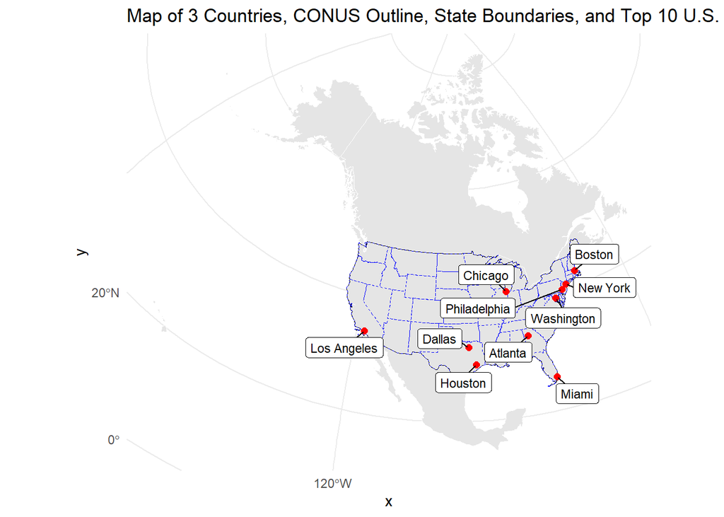

```r
countries <- rnaturalearth::ne_countries(scale = "medium", returnclass = "sf")
US_CAN_MX <- countries %>%
  filter(admin %in% c("United States of America", "Canada", "Mexico"))

conus_outline <- states %>%
  filter(!name %in% c("Alaska", "Hawaii", "Puerto Rico",
                      "American Samoa", "Guam",
                      "Northern Mariana Islands", "United States Virgin Islands"))


conus_outline <- st_union(conus_outline)
conus_outline <- st_as_sf(conus_outline)

countries_proj <- st_transform(US_CAN_MX, 2163)
states_proj <- st_transform(states, 2163)
cities_proj <- st_transform(cities, 2163)
conus_outline_proj <- st_transform(conus_outline, 2163)

top10_cities <- cities_proj %>%
  arrange(desc(population)) %>%
  slice(1:10)

ggplot() +
  geom_sf(data = countries_proj, fill = "grey90", color = "white") +
  geom_sf(data = conus_outline_proj, fill = NA, color = "black", lty = 1, size = 1) +
  geom_sf(data = states_proj, fill = NA, color = "blue", lty = 2, size = 0.5) +
  geom_sf(data = top10_cities, color = "red", size = 2) +
  ggrepel::geom_label_repel(data = top10_cities,
                            aes(label = city, geometry = geometry),
                            stat = "sf_coordinates",
                            size = 3,
                            min.segment.length = 0) +
  theme_minimal() +
  labs(title = "Map of 3 Countries, CONUS Outline, State Boundaries, and Top 10 U.S. Cities")
```

3.2

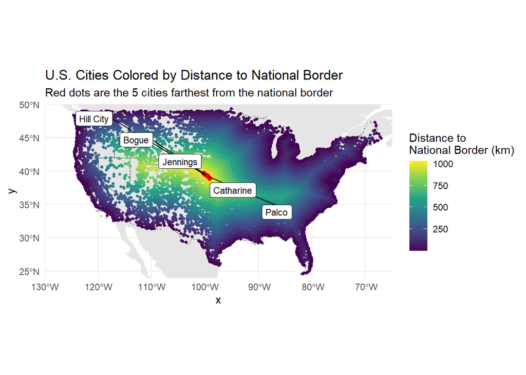

```r
# Union all U.S. states into one geometry
states_union <- st_union(states_proj)

# Get the outer boundary (national border)
usa_border <- st_boundary(states_union) %>%
  st_cast("MULTILINESTRING")

# Calculate distance from each city to the national border
dist_to_border <- st_distance(cities_proj, usa_border)

# Add distance in kilometers to your city data
cities_proj <- cities_proj %>%
  mutate(dist_to_natl_border_km = apply(dist_to_border, 1, min) / 1000)


top5_BorderCities <- cities_proj %>%
  arrange(desc(dist_to_natl_border_km)) %>%
  slice(1:5)



ggplot() +
  # Country background (optional)
  geom_sf(data = US_CAN_MX, fill = "grey90", color = "white") +

  # State outlines
  geom_sf(data = states_proj, fill = NA, color = "black", lty = 2, size = 0.3) +

  # All cities, colored by distance to national border
  geom_sf(data = cities_proj, aes(color = dist_to_natl_border_km), size = 1) +

  # Top 5 farthest cities highlighted in red
  geom_sf(data = top5_BorderCities, color = "red", size = 2) +

  # City labels
  ggrepel::geom_label_repel(
    data = top5_BorderCities,
    aes(label = city, geometry = geometry),
    stat = "sf_coordinates",
    size = 3
  ) +

  # Color scale and labels
  scale_color_viridis_c(name = "Distance to\nNational Border (km)") +
  theme_minimal() +
  labs(
    title = "U.S. Cities Colored by Distance to National Border",
    subtitle = "Red dots are the 5 cities farthest from the national border"
  )+
  coord_sf(xlim = c(-130, -65), ylim = c(24, 50), expand = FALSE)
```

3.3

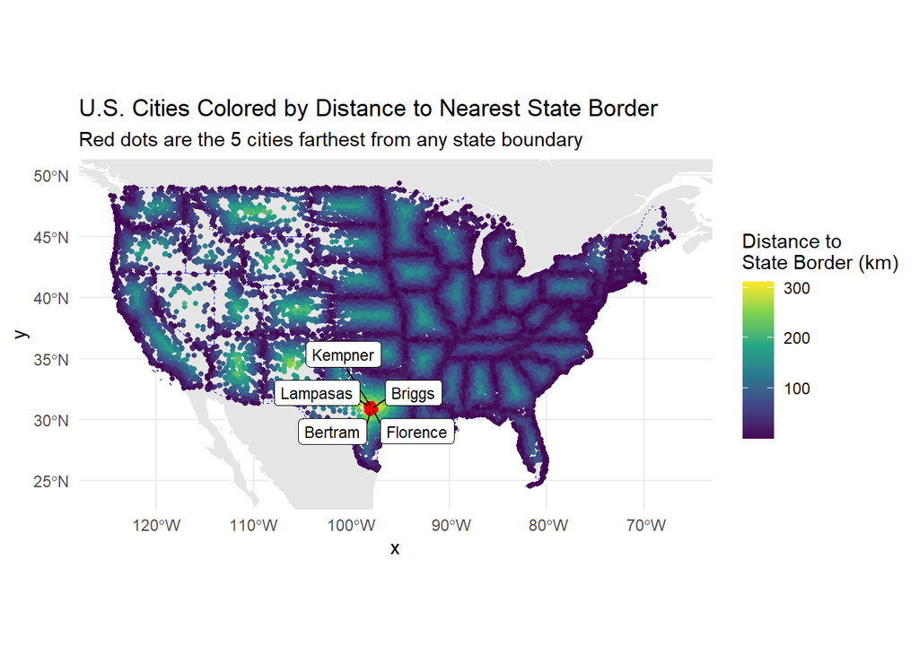

```r
library(ggplot2)
library(ggrepel)

cities_proj <- cities_proj %>%
  filter(!state_name %in% c("Alaska", "Hawaii", "Puerto Rico", "Virgin Islands", "Guam"))

states_proj <- states_proj %>%
  filter(!state_name %in% c("Alaska", "Hawaii", "Puerto Rico", "Virgin Islands", "Guam"))

cities_proj$dist_to_state_border_km <- st_distance(cities_proj, all_state_borders) %>%
  set_units("km") %>%
  as.numeric()

top5_state_border <- cities_proj %>%
  arrange(desc(dist_to_state_border_km)) %>%
  slice(1:5)

ggplot() +
  geom_sf(data = US_CAN_MX, fill = "grey90", color = "white") +
  geom_sf(data = states_proj, fill = NA, color = "blue", lty = 2, size = 0.5) +
  geom_sf(data = cities_proj, aes(color = dist_to_state_border_km), size = 1) +
  geom_sf(data = top5_state_border, color = "red", size = 2.5) +
  ggrepel::geom_label_repel(data = top5_state_border,
                            aes(label = city, geometry = geometry),
                            stat = "sf_coordinates",
                            size = 3,
                            min.segment.length = 0) +
  scale_color_viridis_c(name = "Distance to\nState Border (km)") +
  theme_minimal() +
  labs(
    title = "U.S. Cities Colored by Distance to Nearest State Border",
    subtitle = "Red dots are the 5 cities farthest from any state boundary"
  ) +
  coord_sf(
    xlim = c(-125, -66),
    ylim = c(24, 50)
)
```

3.4

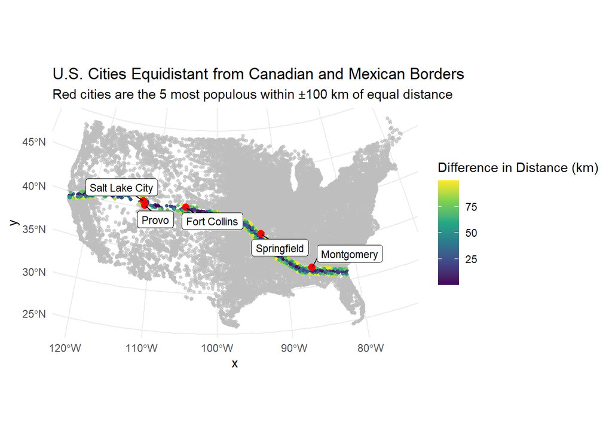

```r
cities_proj <- cities_proj %>%
  mutate(
    dist_to_mexico_km = as.numeric(set_units(st_distance(geometry, mexico_border), "km")),
    dist_to_canada_km = as.numeric(set_units(st_distance(geometry, canada_border), "km"))
  )

cities_proj <- cities_proj %>%
  mutate(border_diff = abs(dist_to_mexico_km - dist_to_canada_km))

equal_dist_cities <- cities_proj %>%
  filter(border_diff <= 100)

top5_equal_pop <- equal_dist_cities %>%
  arrange(desc(population)) %>%
  slice(1:5)

library(gghighlight)

ggplot(data = cities_proj) +
  geom_sf(aes(color = border_diff), size = 1) +
  gghighlight(border_diff <= 100, use_direct_label = FALSE) +
  geom_sf(data = top5_equal_pop, color = "red", size = 2.5) +
  ggrepel::geom_label_repel(data = top5_equal_pop,
                            aes(label = city, geometry = geometry),
                            stat = "sf_coordinates",
                            size = 3,
                            min.segment.length = 0) +
  scale_color_viridis_c(name = "Difference in Distance (km)") +
  theme_minimal() +
  labs(
    title = "U.S. Cities Equidistant from Canadian and Mexican Borders",
    subtitle = "Red cities are the 5 most populous within ±100 km of equal distance"
  )
```

QUESTION 4 4.1

```r
cities <- read_csv("uscities.csv")
cities_sf <- st_as_sf(cities, coords = c("lng", "lat"), crs = 4326)

library(rnaturalearth)
us_border <- ne_countries(country = "United States of America", scale = "medium", returnclass = "sf")

cities_proj <- st_transform(cities_sf, 3395)
us_border_proj <- st_transform(us_border, 3395)

border_buffer <- st_buffer(us_border_proj, dist = 160000)  # 160 km = 160,000 m

cities_in_zone <- cities_proj[st_within(cities_proj, border_buffer, sparse = FALSE), ]

num_cities_in_zone <- nrow(cities_in_zone)
population_in_zone <- sum(cities_in_zone$population, na.rm = TRUE)
total_population <- sum(cities$population, na.rm = TRUE)
percent_in_zone <- (population_in_zone / total_population) * 100

report <- tibble(
  Metric = c(
    "Cities within 100 miles of border",
    "Population within 100 miles of border",
    "Total U.S. city population (in dataset)",
    "Percent of total population in zone"
  ),
  Value = c(
    num_cities_in_zone,
    population_in_zone,
    total_population,
    sprintf("%.2f%%", percent_in_zone)
  )
)


print(report)
```

```
# A tibble: 4 × 2
  Metric                                  Value
  <chr>                                   <chr>
1 Cities within 100 miles of border       30973
2 Population within 100 miles of border   398421566
3 Total U.S. city population (in dataset) 402301854
4 Percent of total population in zone     99.04%
```

Connecticut, Delaware, Florida, Hawaii, Maine, Massachusetts, New Hampshire, New Jersey, New York, Rhode Island and Vermont lie entirely or almost entirely within this area.

Nine of the ten largest U.S. metropolitan areas, as determined by the 2010 Census, also fall within this zone: New York City, Los Angeles, Chicago, Houston, Philadelphia, Phoenix, San Antonio, San Diego and San Jose.

4.2 to 160 in gghighlight

[figure not shown]

```r
top_10 <- cities_in_zone %>%
  top_n(10, wt = population)

ggplot() +
  # Plot all cities as light background points (optional)
  geom_sf(data = cities_proj, color = "gray80", size = 0.5) +

  # Highlight cities within 100-mile zone
  geom_sf(data = cities_in_zone, aes(color = population), size = 1.5) +
  scale_color_gradient(low = "orange", high = "darkred") +

  # Add US boundary
  geom_sf(data = us_border_proj, fill = NA, color = "black", size = 0.4) +

  # Add labels to top 10 populous cities
  geom_text(data = top_10,
            aes(x = st_coordinates(geometry)[,1],
                y = st_coordinates(geometry)[,2],
                label = city),
            size = 3,
            color = "black",
            fontface = "bold",
            check_overlap = TRUE) +

  gghighlight(TRUE) +  # just to emphasize we're using the package
  theme_minimal() +
  labs(
    title = "Cities within 100 Miles of the U.S. Border",
    subtitle = "Top 10 most populous cities labeled",
    color = "Population"
  )
```

4.3

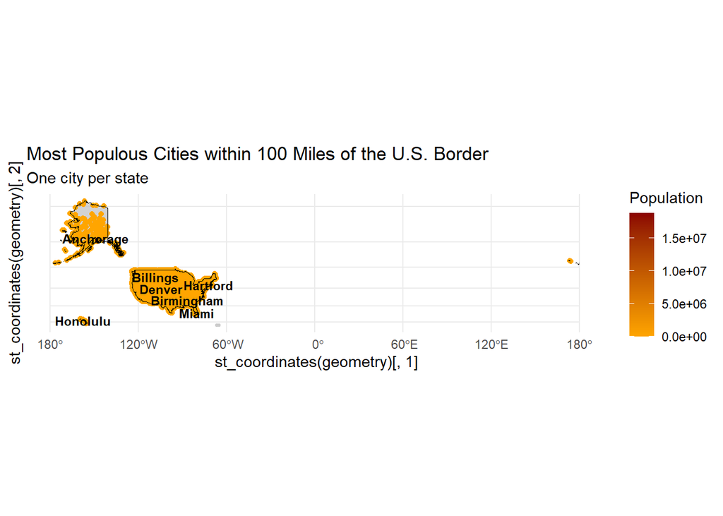

```r
top_city_per_state <- cities_in_zone %>%
  group_by(state_id) %>%
  slice_max(order_by = population, n = 1, with_ties = FALSE) %>%
  ungroup()

top_city_per_state <- cities_in_zone %>%
  group_by(state_id) %>%
  slice_max(order_by = population, n = 1, with_ties = FALSE) %>%
  ungroup()

ggplot() +
  # Background cities (optional)
  geom_sf(data = cities_proj, color = "gray80", size = 0.5) +

  # Highlight cities in the 100-mile danger zone
  geom_sf(data = cities_in_zone, aes(color = population), size = 1.5) +
  scale_color_gradient(low = "orange", high = "darkred") +

  # US border
  geom_sf(data = us_border_proj, fill = NA, color = "black", size = 0.4) +

  # Label most populous city per state in the danger zone
  geom_text(
    data = top_city_per_state,
    aes(x = st_coordinates(geometry)[, 1],
        y = st_coordinates(geometry)[, 2],
        label = city),
    size = 3,
    color = "black",
    fontface = "bold",
    check_overlap = TRUE
  ) +

  gghighlight(TRUE) +
  theme_minimal() +
  labs(
    title = "Most Populous Cities within 100 Miles of the U.S. Border",
    subtitle = "One city per state",
    color = "Population"
  )
```